# Lecture 8

## Model 1 - Implementation

Fit the model

```r
cmp = ~ Intercept(1) +
  time(time, model = "rw2") +
  space(geometry, model = spde)

lik = bru_obs(formula =  Y~ .,
              data = dd)

fit_1 = bru(cmp, lik)

# plot time effect

p = fit_1$summary.random$time %>%
  ggplot() +
  geom_ribbon(aes(ID,
                  ymin = `0.025quant`,
                  ymax = `0.975quant`),
              alpha = 0.5) +
  geom_line(aes(ID, mean))
```

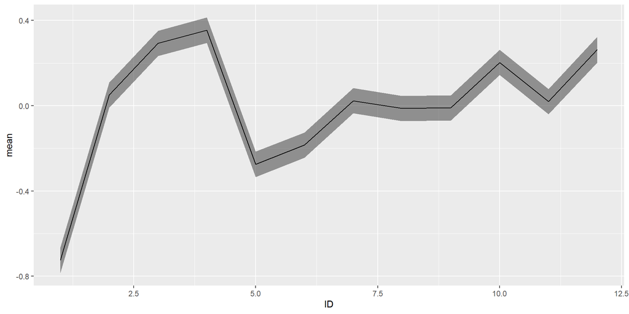

## Model 1 - Implementation

Space-time Predictions

```r
pxl = fm_pixels(mesh, mask = border)

pxl_time = fm_cprod(pxl, data.frame(time = seq(1,12)))

pred_1 = predict(fit_1, pxl_time, ~ data.frame(mu = Intercept + space + time,
                                      time_effect = time,
                                      space_effect = space))
```

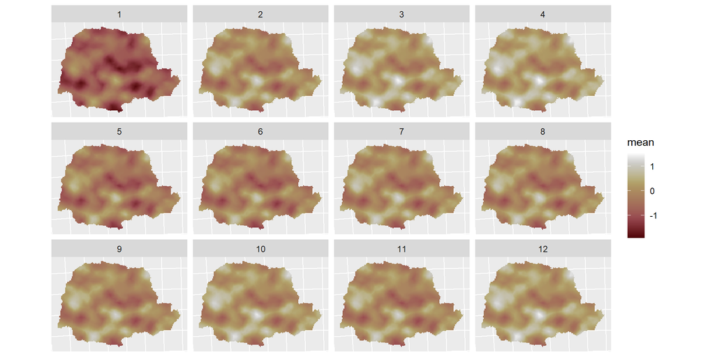

## Spatio temporal models for areal data

The observation model

$$Y_t(s)|\mu_t(s)\sim\mathcal{N}(\mu_t(s),\sigma_y^2); \qquad \eta_t(s) = \mu_t(s)$$

We are going to see **3 different models for the linear predictor** $\eta_{st}$

1. **Model 1**: $\eta_t(s) = \beta_0 + u(s) + v_t$ with $u(s)\sim\text{GF}(\rho,\sigma_u)$

   Here the time effect $v_t$ is constant w.r.t. space and the space effect $u(s)$ is constant w.r.t. time.
2. **Model 2**: $\eta_t(s) = \beta_0 + u_t(s) + v_t$ with $u_t(s)\sim\text{GF}(\rho,\sigma_u),\ t = 1,\dots,T$

   Here spatial fields are different for each year, are independent and share range and sd.

## Model 2 - Implementation

Fit the model

```r
cmp = ~ Intercept(1) +
  time(time, model = "rw2") +
  space(geometry, model = spde,
        replicate = time)

lik = bru_obs(formula =  Y~ .,
              data = dd)

fit_2 = bru(cmp, lik)

# plot time effect

p = fit_2$summary.random$time %>%
  ggplot() +
  geom_ribbon(aes(ID,
                  ymin = `0.025quant`,
                  ymax = `0.975quant`),
              alpha = 0.5) +
  geom_line(aes(ID, mean))
```

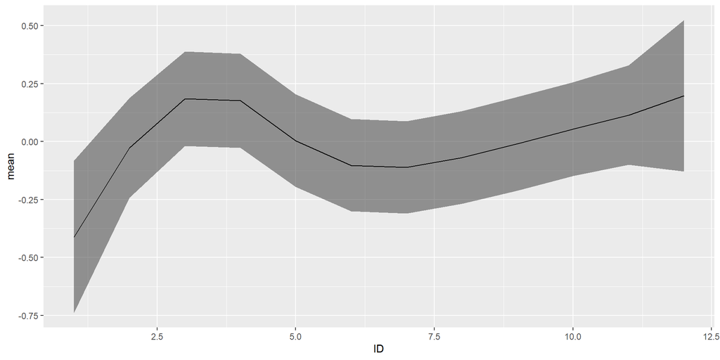

## Model 2 - Implementation

Space-time Predictions

```r
pred_2 = predict(fit_2, pxl_time, ~ data.frame(mu = Intercept + space + time,
                                      time_effect = time,
                                      space_effect = space))
```

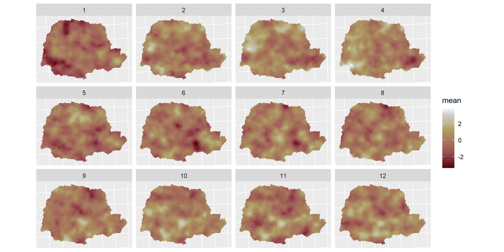

## Spatio temporal models for areal data

The observation model

$$Y_t(s)|\mu_t(s)\sim\mathcal{N}(\mu_t(s),\sigma_y^2); \qquad \eta_t(s) = \mu_t(s)$$

We are going to see **3 different models for the linear predictor** $\eta_{st}$

1. **Model 1**: $\eta_t(s) = \beta_0 + u(s) + v_t$ with $u(s)\sim\text{GF}(\rho,\sigma_u)$

   Here the time effect $v_t$ is constant w.r.t. space and the space effect $u(s)$ is constant w.r.t. time.
2. **Model 2**: $\eta_t(s) = \beta_0 + u_t(s) + v_t$ with $u_t(s)\sim\text{GF}(\rho,\sigma_u),\ t = 1,\dots,T$

   Here spatial fields are different for each year, are independent and share range and sd.
3. **Model 3**: $\eta_t(s) = \beta_0 + u_t(s) + v_t$ with
   $$u_t(s) = \phi\ u_{t-1}(s) + \omega(s),\text{ with } \omega(s)\sim\text{GF}(\rho,\sigma_u)$$

## Model 3 - Implementation

Fit the model

```r
h.spec <- list(rho = list(prior = 'pc.cor1',
                          param = c(0, 0.9)))
cmp = ~ Intercept(1) +
  time(time, model = "rw2") +
  space(geometry, model = spde,
        group = time,
        control.group = list(model = 'ar1',
                             hyper = h.spec))

lik = bru_obs(formula =  Y~ .,
              data = dd)

fit_3 = bru(cmp, lik)

# plot time effect

p = fit_3$summary.random$time %>%
  ggplot() +
  geom_ribbon(aes(ID,
                  ymin = `0.025quant`,
                  ymax = `0.975quant`),
              alpha = 0.5) +
  geom_line(aes(ID, mean))
```

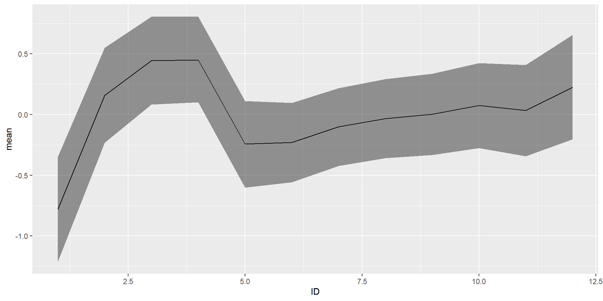

## Model 3 - Implementation

Space-time Predictions

```r
pred_3 = predict(fit_3, pxl_time, ~ data.frame(mu = Intercept + space + time,
                                      time_effect = time,
                                      space_effect = space))
```

[figure not shown]

## Adding covariates to space-time models

- Covariates that only vary in space
  - Altitude, bathimetry,…
- Covariates that vary in space *and* time
  - Temperature, precipitation, …

## Space covariates

- They should be stored in a `terra`, `SpatRaster` object.

```r
library(terra)
library(tidyterra)
```

```r
cov_space
```

```
class       : SpatRaster
size        : 147, 147, 1  (nrow, ncol, nlyr)
resolution  : 4.465128, 3.11244  (x, y)
extent      : -465.4573, 190.9165, 7031.885, 7489.413  (xmin, xmax, ymin, ymax)
coord. ref. : +proj=utm +zone=23 +south +datum=WGS84 +units=km +no_defs
source(s)   : memory
name        :      last
min value   : -1.817284
max value   :  3.174626
```

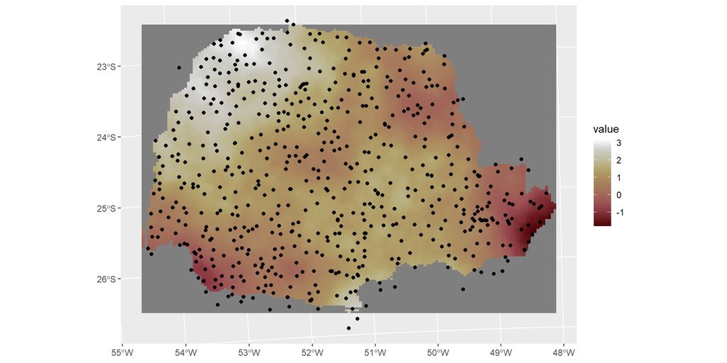

```r
ggplot()  + geom_spatraster(data = cov_space) + geom_sf(data = dd) + scale_fill_scico()
```

## Space covariates - Implementation

Setting up and running the model

```r
cmp1 = ~ Intercept(1) +
  time(time, model = "rw2") +
  space(geometry, model = spde) +
  cov(cov_space,  model = "linear")

lik1 = bru_obs(formula =  Y~ .,
              data = dd_1)

fit_cov1 = bru(cmp1, lik1)
```

Look at the results

```r
round(fit_cov1$summary.fixed,2)
```

```
           mean   sd 0.025quant 0.5quant 0.975quant  mode kld
Intercept -0.11 0.22      -0.57    -0.10       0.32 -0.11   0
cov       -1.42 0.09      -1.60    -1.42      -1.23 -1.42   0
```

## Space-time covariates

Some covariates change in both space and time.

There are several ways of doing this….many quite confusing 🤪

Here is one recipe !

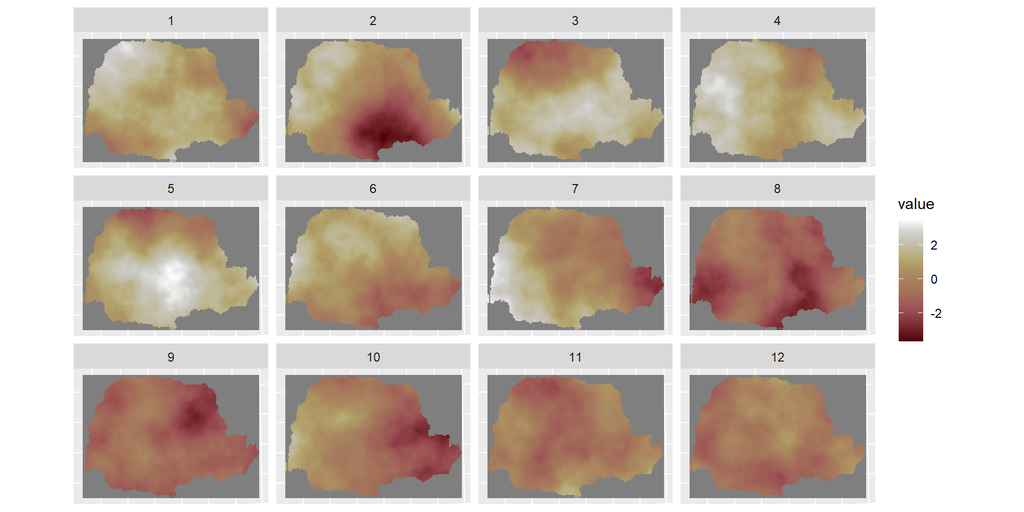

## Space-time covariates

- Have the covariate as a multilier `spatraster` object

```r
# The covariate
cov_space_time
```

```
class       : SpatRaster
size        : 147, 147, 12  (nrow, ncol, nlyr)
resolution  : 4.465128, 3.11244  (x, y)
extent      : -465.4573, 190.9165, 7031.885, 7489.413  (xmin, xmax, ymin, ymax)
coord. ref. : +proj=utm +zone=23 +south +datum=WGS84 +units=km +no_defs
source(s)   : memory
names       :         1,         2,         3,         4,         5,         6, ...
min values  : -1.817284, -3.632524, -2.193592, -1.161786, -2.028409, -1.686606, ...
max values  :  3.174626,  2.660178,  2.839714,  3.143044,  3.531395,  3.208386, ...
```

```r
# The data frame
dd_1[1:3,]
```

```
Simple feature collection with 3 features and 2 fields
Geometry type: POINT
Dimension:     XY
Bounding box:  xmin: -103.4191 ymin: 7460.922 xmax: -103.4191 ymax: 7460.922
Projected CRS: +proj=utm +zone=23 +south +datum=WGS84 +units=km +no_defs +type=crs
# A tibble: 3 × 3
      Y  time             geometry
  <dbl> <dbl>         <POINT [km]>
1 -2.18     1 (-103.4191 7460.922)
2 -1.07     5 (-103.4191 7460.922)
3 -3.97     6 (-103.4191 7460.922)
```

**Note** The layers names in the raster are the same as the elements of the column `time` in the data.

## Space-time covariates

Implementation

```r
cmp1 = ~ Intercept(1) +
  time(time, model = "rw2") +
  space(geometry, model = spde) +
  cov(eval_spatial(cov_space_time, .data.,  time),  model = "linear")

lik1 = bru_obs(formula =  Y~ .,
              data = dd_1)

fit_cov1 = bru(cmp1, lik1)

round(fit_cov1$summary.fixed)
```

```
          mean sd 0.025quant 0.5quant 0.975quant mode kld
Intercept    0  0         -1        0          0    0   0
cov         -1  0         -1       -1         -1   -1   0
```

The `.data.` indicates the data that are input in the `bru_obs()` function

# Point Processes

## Space-time Point Processes

- For space-time point processes one can also use the `group` and `replicate` features
- The one difference is that one has to define the integration scheme in both space and time!

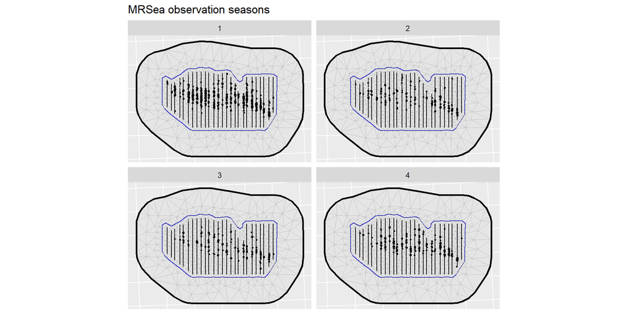

## Space-time Point Processes

1. Define the component (with the `group` feature)

```r
cmp <- ~ Intercept(1) +
  space_time(geometry,
             model = matern,
    group = season,
    ngroup = 4 )

lik =  bru_obs(
    geometry + season ~ .,
    family = "cp",
    data = mrsea$points,
    samplers = mrsea$samplers,
    domain = list(
      geometry = mrsea$mesh,
      season = seq_len(4)
    ))

fit <- bru(cmp, lik)
```

## Space-time Point Processes

1. Define the component (with the `group` feature)
2. Define the likelihood model

```r
cmp <- ~ Intercept(1) +
  space_time(geometry,
             model = matern,
    group = season,
    ngroup = 4 )

lik =  bru_obs(
    geometry + season ~ .,
    family = "cp",
    data = mrsea$points,
    samplers = mrsea$samplers,
    domain = list(
      geometry = mrsea$mesh,
      season = seq_len(4)
    ))

fit <- bru(cmp, lik)
```

## Space-time Point Processes

1. Define the component (with the `group` feature)
2. Define the likelihood model
- Where is our process defined (space and time)

```r
cmp <- ~ Intercept(1) +
  space_time(geometry,
             model = matern,
    group = season,
    ngroup = 4 )

lik =  bru_obs(
    geometry + season ~ .,
    family = "cp",
    data = mrsea$points,
    samplers = mrsea$samplers,
    domain = list(
      geometry = mrsea$mesh,
      season = seq_len(4)
    ))

fit <- bru(cmp, lik)
```

## Space-time Point Processes

1. Define the component (with the `group` feature)
2. Define the likelihood model
- Where is our process defined (space and time)
- Domain of integration

```r
cmp <- ~ Intercept(1) +
  space_time(geometry,
             model = matern,
    group = season,
    ngroup = 4 )

lik =  bru_obs(
    geometry + season ~ .,
    family = "cp",
    data = mrsea$points,
    samplers = mrsea$samplers,
    domain = list(
      geometry = mrsea$mesh,
      season = seq_len(4)))

fit <- bru(cmp, lik)
```

## Space-time Point Processes

1. Define the component (with the `group` feature)
2. Define the likelihood model
3. Run the model (as usual)

```r
cmp <- ~ Intercept(1) +
  space_time(geometry,
             model = matern,
    group = season,
    ngroup = 4 )

lik =  bru_obs(
    geometry + season ~ .,
    family = "cp",
    data = mrsea$points,
    samplers = mrsea$samplers,
    domain = list(
      geometry = mrsea$mesh,
      season = seq_len(4)))

fit <- bru(cmp, lik)
```

## Space-time Point Processes

Results

```r
ppxl <- fm_pixels(mrsea$mesh, mask = mrsea$boundary, format = "sf")
ppxl_all <- fm_cprod(ppxl, data.frame(season = seq_len(4)))

lambda1 <- predict( fit,ppxl_all,
  ~ data.frame(season = season, lambda = exp(space_time + Intercept)))
```

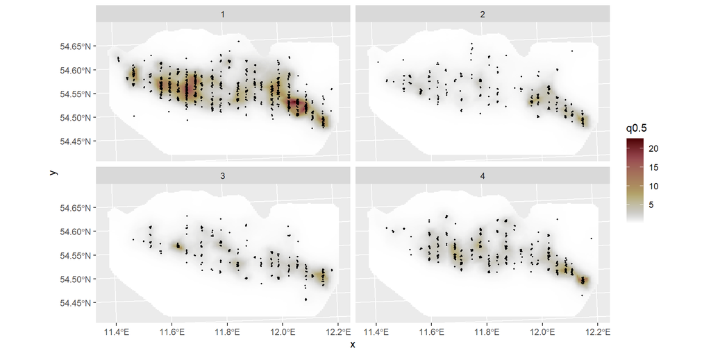

## Other spatial/spatio-temporal models

- The Barrier model

*Bakka et al. Non-stationary Gaussian models with physical barriers, Spatial Statistics (2019)*

That could be interesting in many of your studies!!

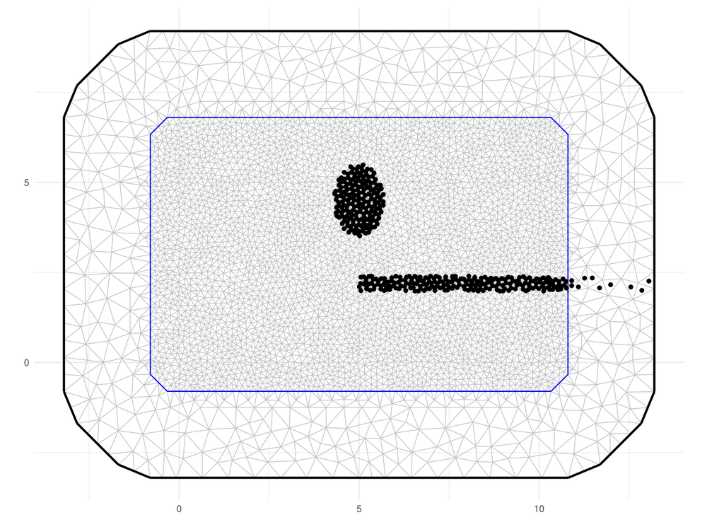

## Other spatial/spatio-temporal models

- The Barrier model

*Bakka et al. Non-stationary Gaussian models with physical barriers, Spatial Statistics (2019)*

That could be interesting in many of your studies!!

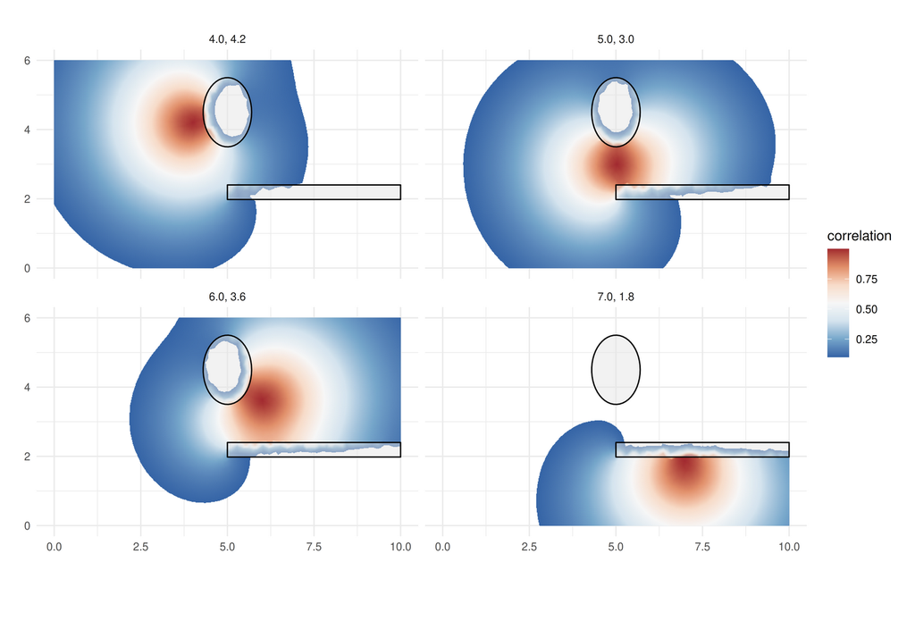

## Other spatial/spatio-temporal models

- The Barrier model

*Bakka et al. Non-stationary Gaussian models with physical barriers, Spatial Statistics (2019)*

That could be interesting in many of your studies!!

- Some non-separable models are implemented in `inlabru`. See

*Lindgrenn et al., A diffusion-based spatio-temporal extension of Gaussian Matern fields (2024) SORT 48*

Here they introduce a diffusion-type process that evolves in space and time.

- Rational Approximations of Fractional SPDE

*David Bolin, Alexandre B. Simas, Zhen Xiong (2024), Covariance-based rational approximations of fractional SPDEs for computationally efficient Bayesian inference. Journal of Computational and Graphical Statistics, 33:1, 64-74*